# Optimal Temperature Kernels for Simulated Tempering

Algorithms Seminar · Department of Statistics, University of Warwick

**Hugo Queniat**<sup>1</sup>, Gareth O. Roberts<sup>1</sup>, Nicholas G. Tawn<sup>1</sup>

<sup>1</sup>University of Warwick

13 November 2026

[figure not shown]

[figure not shown]

[figure not shown]

Link to slides

## Stochastic Simulation

- **Objective:** Compute $\pi(f) = \mathbb{E}_{\pi}[f(X)]$ where $\pi$ is known up to a normalizing constant.
- **Markov chain Monte Carlo (MCMC):**
  - Construct an ergodic **Markov chain** $\{X_t:t\geq1\}$ with **stationary distribution** $\pi$.
  - Compute the ergodic average $\hat{\pi}_T(f) = \frac{1}{T}\sum_{t=1}^T f(X_t)$.

## Challenge for MCMC: Multimodality

- Typical MCMC (**RWM**, **MALA**) rely on **localized proposals**:
  - they excel at **exploring a single mode**,
  - but struggle to **transition between modes**.

Informally, when $\pi = \sum \pi_k$:
$$T_\text{mix}(\pi_k) \ll T_\text{mix}(\pi)$$

## Running Example: a Mixture of Two Gaussians

A simple **mixture** of **two** Gaussian distributions:
$$\pi({\bf x}) = \tfrac{1}{2}\,\mathrm{N}\!\left({\bf x};\,\textcolor{#ef6c00}{m},\, \sigma^2 I_d\right) + \tfrac{1}{2}\,\mathrm{N}\!\left({\bf x};\, \textcolor{#ef6c00}{-m},\, \sigma^2 I_d\right)$$

[video not shown]

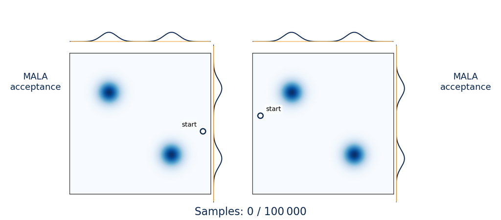

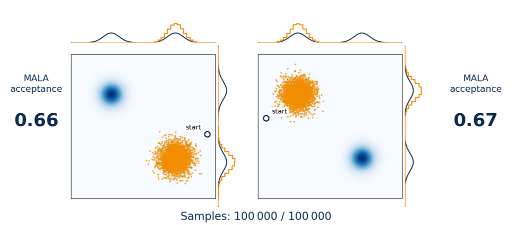

**Well-tuned MALA, and still ⇒ trapped in one mode**

## Outline

1. **Introduction** — Simulated Tempering
2. **Reversible** temperature moves
3. **Non-reversible** temperature moves
4. **Numerical Experiments**
5. **Takeaways & Future Work**

# Simulated Tempering (ST)

## Tempering: Lift the barriers

Introduce an **inverse temperature** $\textcolor{#9c27b0}{\boldsymbol{\beta}}$ and power-temper the **target**:

$$\textcolor{#1565c0}{\pi_{\textcolor{#9c27b0}{\boldsymbol{\beta}}}(x) \propto \pi(x)^{\textcolor{#9c27b0}{\boldsymbol{\beta}}}}, \qquad \textcolor{#9c27b0}{\boldsymbol{\beta}} \in (0,1].$$

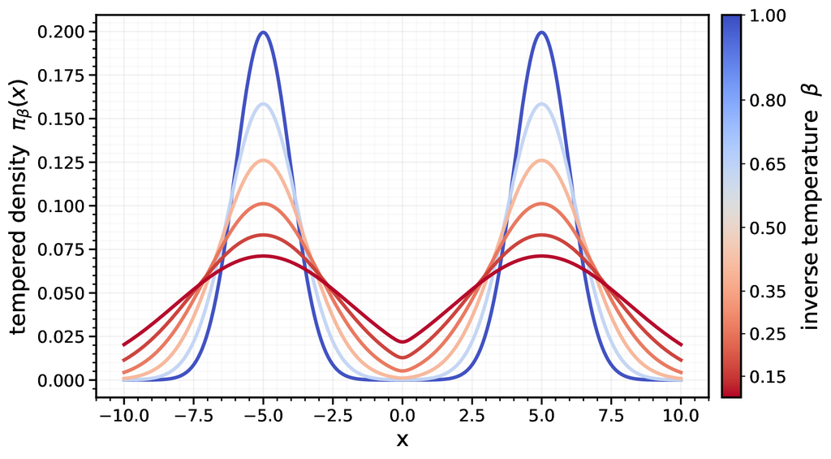

**Cold target** ($\beta=1$) and **warmer distributions** ($\beta\ll1$).

## Multiple Targets

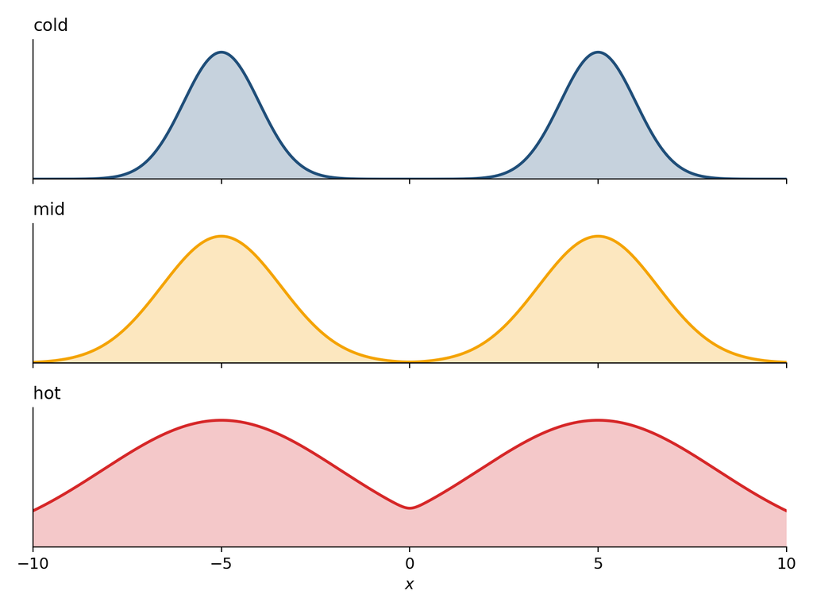

- **Key idea:** a chain that moves **vertically** can escape modes at low $\beta$ …
- … and bring that information back to the **target level** $\beta_0=1$ [KT90; MP92; GT95].

## ST : a Metropolis-within-Gibbs scheme

[video not shown]

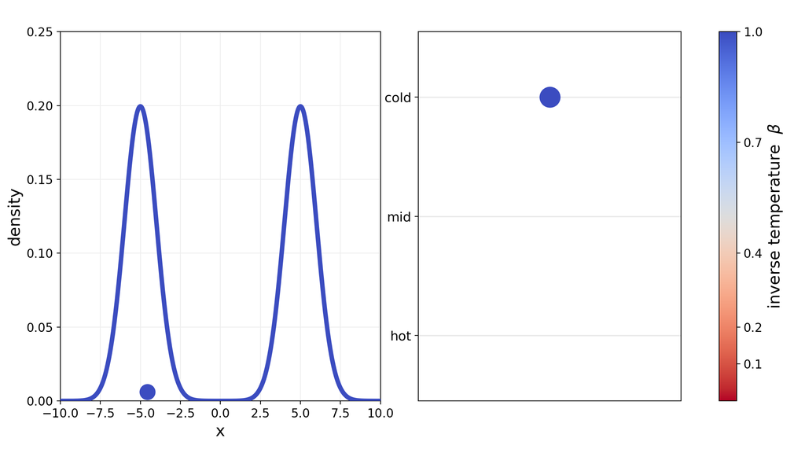

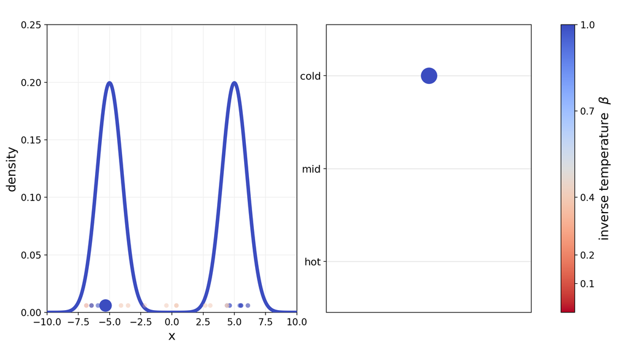

## ST : a Metropolis-within-Gibbs scheme

- **Within-temperature move:** any kernel (RWM, MALA, etc) that leaves $\pi_{\beta}$ invariant.
- **Between-temperature move:** a temperature kernel $T$ that updates $\boldsymbol{\beta}$.

$\bar\pi(\textcolor{#c4cad1}{\beta},\textcolor{#6a1b9a}{x})\;=\;\frac{1}{K+1}\,\frac{\tilde\pi_{\textcolor{#c4cad1}{\beta}}(\textcolor{#6a1b9a}{x})}{\textcolor{#2e7d32}{Z_{\beta}}}\;=\;\frac{1}{K+1}\,\pi_{\textcolor{#c4cad1}{\beta}}(\textcolor{#6a1b9a}{x})$

$\bar\pi(\textcolor{#ef6c00}{\beta},\textcolor{#c4cad1}{x})\;=\;\frac{1}{K+1}\,\frac{\tilde\pi_{\textcolor{#ef6c00}{\beta}}(\textcolor{#c4cad1}{x})}{\textcolor{#2e7d32}{Z_{\beta}}}\;=\;\frac{1}{K+1}\,\pi_{\textcolor{#ef6c00}{\beta}}(\textcolor{#c4cad1}{x})$

[figure not shown]

## Reversible Temperature Dynamics

[figure not shown]

**Detailed balance condition:**

$$\pi_{\beta_k}(x)\, \textcolor{#1565c0}{T\bigl((k,x) \to (k\pm1,x)\bigr)}
\;=\;
\textcolor{#ef6c00}{\pi_{\beta_{k\pm1}}(x)}\, \textcolor{#2e7d32}{T\bigl((k\pm1,x) \to (k,x)\bigr)}$$

**Random Walk ST** [GT95]**:**

$$\textcolor{#1565c0}{T\bigl((k,x) \to (k\pm1,x)\bigr)} = \frac{1}{2} \min\Bigl\{1,\frac{\textcolor{#ef6c00}{\pi_{\beta_{k\pm1}}(x)}}{\pi_{\beta_k}(x)}\Bigr\}$$

## Can we drive the chain in one direction?

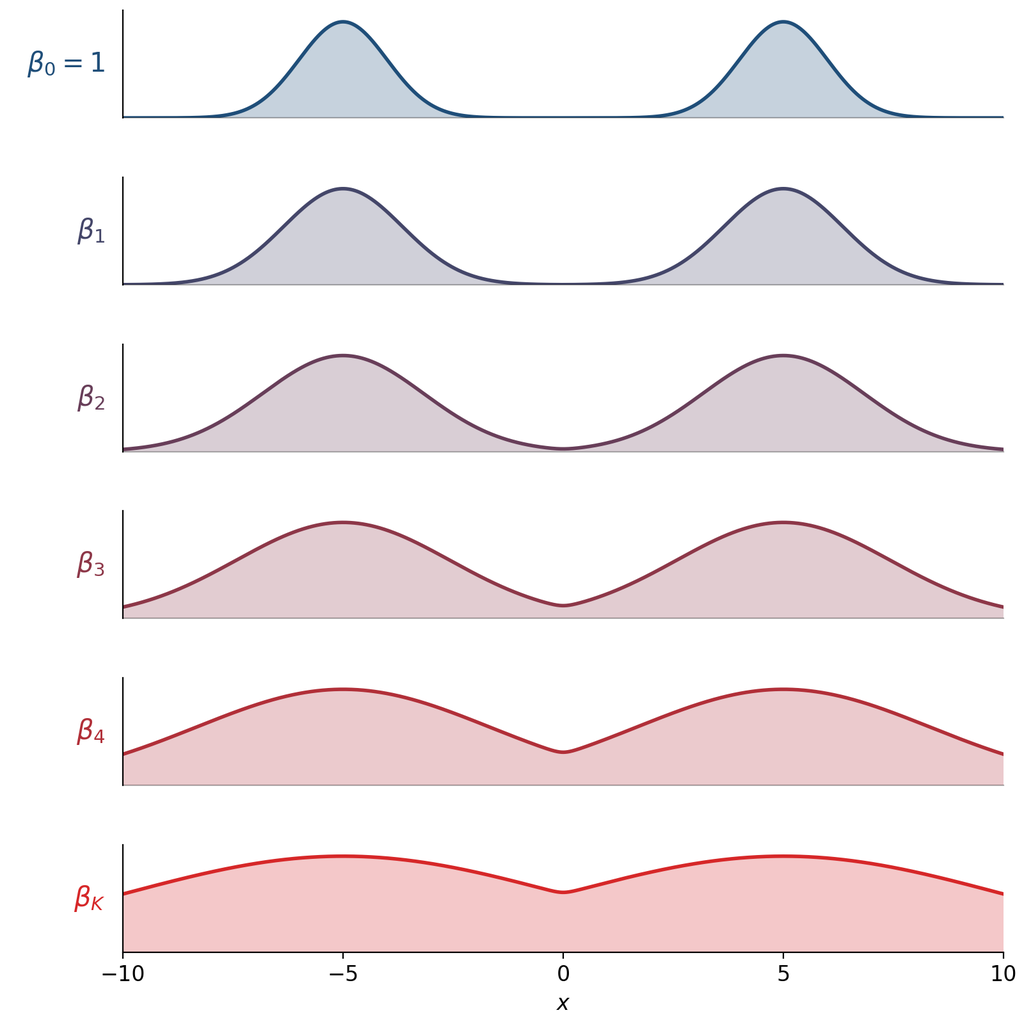

[figure not shown]

- **Heat up**: keep moving **down** the ladder to get a **fresh** sample.
- **Cool down**: keep moving back **up**, to bring the new sample towards $\beta_0=1$.

## Lifted Temperature Dynamics [CLP99; DHN00; SH16]

[figure not shown]

$(\textcolor{#ef6c00}{\beta},\textcolor{#6a1b9a}{x})\in \{\textcolor{#ef6c00}{\beta_0},\dots,\textcolor{#ef6c00}{\beta_K}\}\times\textcolor{#6a1b9a}{\mathcal X},\qquad \bar\pi(\textcolor{#ef6c00}{\beta},\textcolor{#6a1b9a}{x})\;\propto\;\pi_{\textcolor{#ef6c00}{\beta}}(\textcolor{#6a1b9a}{x})$

$(\textcolor{#ef6c00}{\beta},\textcolor{#6a1b9a}{x},\nu)\in \{\textcolor{#ef6c00}{\beta_0},\dots,\textcolor{#ef6c00}{\beta_K}\}\times\textcolor{#6a1b9a}{\mathcal X}\times\{\textcolor{#1565c0}{+1},\textcolor{#1565c0}{-1}\},\qquad \bar\pi(\textcolor{#ef6c00}{\beta},\textcolor{#6a1b9a}{x},\nu)=\textcolor{#2e7d32}{\dfrac{1}{2}}\,\bar\pi(\textcolor{#ef6c00}{\beta},\textcolor{#6a1b9a}{x})$

uniform marginal on the velocity $\nu$

$(\textcolor{#ef6c00}{\beta},\textcolor{#6a1b9a}{x},\nu)\in \{\textcolor{#ef6c00}{\beta_0},\dots,\textcolor{#ef6c00}{\beta_K}\}\times\textcolor{#6a1b9a}{\mathcal X}\times\{\textcolor{#1565c0}{+1},\textcolor{#c62828}{-1}\},\qquad \bar\pi(\textcolor{#ef6c00}{\beta},\textcolor{#6a1b9a}{x},\nu)=\textcolor{#2e7d32}{\dfrac{1}{2}}\,\bar\pi(\textcolor{#ef6c00}{\beta},\textcolor{#6a1b9a}{x})$

uniform marginal on the velocity $\nu$

**Skew detailed balance condition:**

$$\pi_{\beta_k}(x)\, \textcolor{#1565c0}{T^{\nu}\bigl((k,x) \to (j,x)\bigr)}
\;=\;
\textcolor{#ef6c00}{\pi_{\beta_j}(x)}\, \textcolor{#c62828}{T^{-\nu}\bigl((j,x) \to (k,x)\bigr)}$$

**Guided Walk ST [Gus98; BCB25]:**

$$\textcolor{#1565c0}{T\bigl((k,x,\nu) \to (k+\nu,x,\nu)\bigr)} = \min\Bigl\{1,\frac{\textcolor{#ef6c00}{\pi_{\beta_{k+\nu}}(x)}}{\pi_{\beta_k}(x)}\Bigr\},
\quad \text{else } \nu \to -\nu$$

## Optimal Scaling in a Tempering Setting

**Framework** [ARR11; RR14; RRT22]: a **target of $\color{#2980B9}{d}$ iid components** [RR01], tempered within a **single mode**, so that **spatial mixing is immediate**.

**Theorem** [ARR11]. To keep the algorithm **non-degenerate** as $\color{#2980B9}{d} \to \infty$, the temperature spacing must scale as
$$\left|\beta_{k\pm 1}-\beta_k\right| \;\sim\; \color{#FF8C00}{\ell}\, \color{#2980B9}{d^{-1/2}}.$$

**How do we choose $\color{#FF8C00}{\ell}$?**

## Optimal Scaling in a Tempering Setting

**Theorem** [RR14, Thm 1]. Let $X^\sigma$ be the $\textcolor{#6a1b9a}{\pi}$-reversible diffusion on an interval
$$dX^\sigma_t = \textcolor{#1565c0}{\sigma}\,dB_t + \big(\tfrac12\,\textcolor{#1565c0}{\sigma^2}\,(\log\textcolor{#6a1b9a}{\pi})' + \textcolor{#1565c0}{\sigma\sigma'}\big)\,dt .$$
If $\textcolor{#1565c0}{\sigma_1 \le \sigma_2}$ pointwise, then $\textcolor{#ef6c00}{\mathrm{Var}_{\mathrm{as}}(h,\sigma_1) \ge \mathrm{Var}_{\mathrm{as}}(h,\sigma_2)}$ for all $h \in L^2(\pi)$.

$\Rightarrow$ Maximise the **volatility** to cut the **asymptotic variance**.

- In tempering, a practical diagnostic is the **round-trip rate** [LDMT09b; SBDD22]: frequency of **full hot-cold-hot** journeys.

[figure not shown]

## Optimal Scaling in a Tempering Setting

[figure not shown]

**Theorem** [RR25; QRT26+]. The **volatility of the diffusion limit** is proportional to the **efficiency metric**:
$$\mathrm{eff}(\ell) \;=\; \textcolor{#ef6c00}{\ell^2}\Bigl(\textcolor{#1565c0}{a_+(\ell) + a_-(\ell)} + \frac{\textcolor{#2e7d32}{(a_+(\ell) - a_-(\ell))^2}}{\textcolor{#c62828}{\rho(\ell)}}\Bigr)$$
with **global movement rate**, **momentum drift** and **flip rate**.

## Current Picture [RR25]

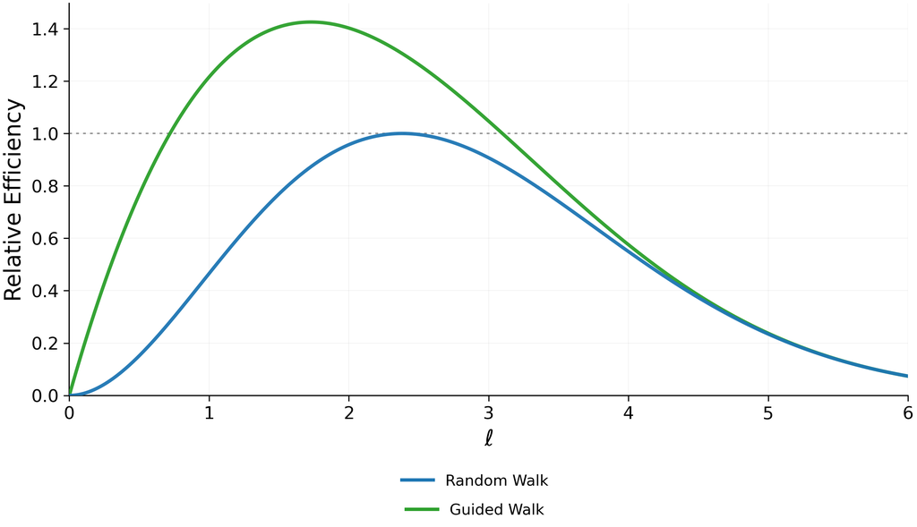

$$\begin{aligned}
a(\ell) &= 2 \Phi\Bigl(-\frac{\ell}{2}\Bigr) \\[1.2em]
\textcolor{#1f77b4}{\mathrm{eff}_{\mathrm{RW}}(\ell)} &= \textcolor{#1f77b4}{\ell^2\, a(\ell)} \\[1.2em]
\textcolor{#2ca02c}{\mathrm{eff}_{\mathrm{GW}}(\ell)} &= \textcolor{#2ca02c}{\ell^2\, \frac{a(\ell)}{1-a(\ell)}}
\end{aligned}$$

**Guided Walk** improves on **Random Walk** by a factor of $\textcolor{#2ca02c}{\sim 1.42}$.

This optimal $\textcolor{#2ca02c}{\ell^\star}$ corresponds to an acceptance rate of $\textcolor{#2ca02c}{\sim 0.387}$.

# Reversible Kernels

## Towards Smarter Temperature Moves

**Reminder:** the **efficiency metric** $\displaystyle \mathrm{eff}(\ell) = \color{#FF8C00}{\ell^2}\, \color{#2980B9}{\mathrm{acc}(\ell)}$

Original construction [GT95] is the simple **Random Walk** [MRR+53]:

$$T((k,\textcolor{#2e7d32}{x}) \to (k\pm 1,\textcolor{#2e7d32}{x})) = \textcolor{#1565c0}{\tfrac{1}{2}} \min \Bigl\{ 1,\, \pi_{\beta_{k \pm 1}}(\textcolor{#2e7d32}{x}) \,/\, \pi_{\beta_{k}}(\textcolor{#2e7d32}{x}) \Bigr\}.$$

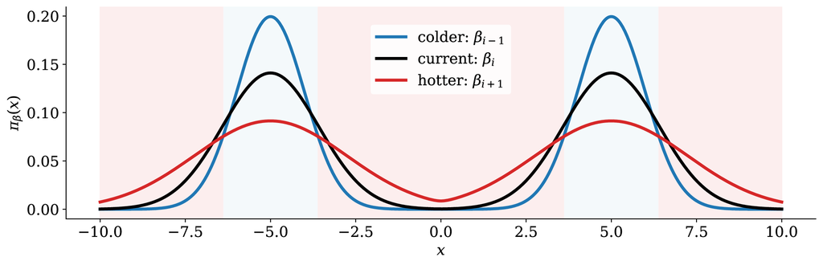

Figure 1: Locations at which **hotter** or **colder** temperatures yield a higher Metropolis ratio.

## Informed Temperature Proposals [Zan20; QRT26+]

Incorporate **state information** to improve **acceptance**:

$$q_g(\beta_k \to \textcolor{#ef6c00}{\beta_j}) \propto g\left(\frac{\pi_{\textcolor{#ef6c00}{\beta_j}}(\textcolor{#2e7d32}{x})}{\pi_{\beta_k}(\textcolor{#2e7d32}{x})}\right)$$
for $g$ nonnegative and nondecreasing.

**Theorem** [QRT26+]. If $g$ is **locally-balanced** [Zan20], i.e. $g(r) = r\,g(1/r)$, then
$$1 - \textcolor{#1565c0}{\mathrm{acc}_{Q_g}(\ell)} = \mathcal{O}\bigl(\textcolor{#ef6c00}{\ell^3}\bigr)$$

## Higher Acceptance for Locally-Balanced Proposals

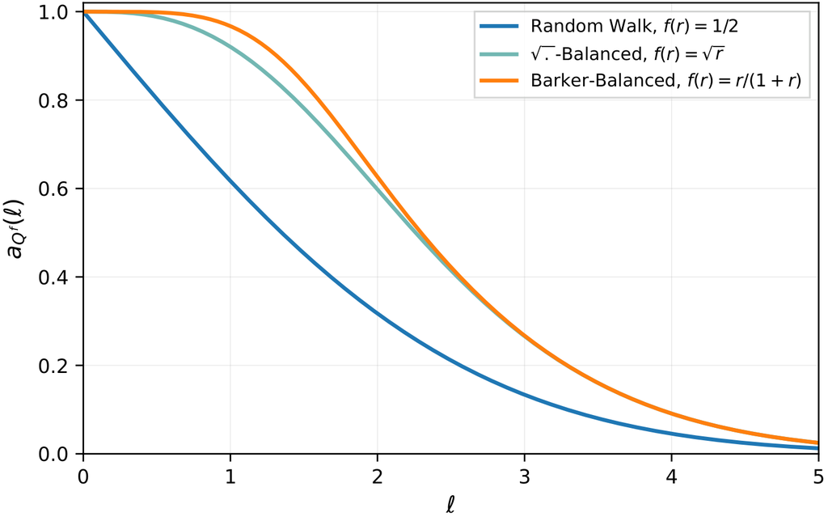

(a) Accepted movement rate

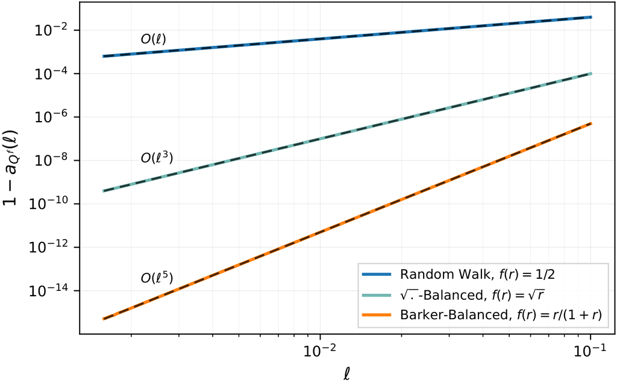

(b) Small-spacing rejection rate

Figure 2

**Theorem** [QRT26+]. For any **reversible** nearest-neighbour temperature kernel $T$, we have $\textcolor{#1565c0}{\mathrm{acc}_T(\ell)} \leq \textcolor{#6a1b9a}{C_{\mathrm{rev}}(\ell)}$, and as $\textcolor{#ef6c00}{\ell} \to \infty$,
$$\textcolor{#6a1b9a}{C_{\mathrm{rev}}(\ell)} \;\sim\; 4\,\Phi\Bigl(-\tfrac{\textcolor{#ef6c00}{\ell}}{2}\Bigr) \;\sim\; \textcolor{#1565c0}{\mathrm{acc}_{Q_g}(\ell)}.$$

## Efficiency Gains from Informed Proposals [QRT26+]

[figure not shown]

Figure 3: **Barker** proposal approaches the reversible efficiency ceiling and dominates **Guided Walk** in their respective optimal regimes.

# Non-Reversible Kernels

## Guided Walk is flawed: Why?

[figure not shown]

where $R_{k,j}=\pi_{\beta_j}(x)/\pi_{\beta_k}(x)$.

$$\mathrm{eff}_{\mathrm{GW}}(\ell)=\ell^2\left(\textcolor{#1565c0}{a(\ell)}+\frac{\textcolor{#2e7d32}{a(\ell)^2}}{\textcolor{#ef6c00}{1 - a(\ell)}}\right),
\qquad a(\ell) = 2\,\Phi\!\left(-\ell/2\right)$$

**Flip upon rejection: can the flip rate $\textcolor{#ef6c00}{\rho(\ell) = 1 - a(\ell)}$ be reduced?**

## Lazy Guided Walk – The TCV Flip Rule [TCV11; FBDR20]

[figure not shown]

where $a_{\pm}=\min\{1,R_{k,k\pm1}\}$.

**Lazy Guided Walk** flips only the **imbalance**  
and keeps the rest as a **lazy** self-transition.

## TCV Flip vs Flip Upon Rejection [QRT26+]

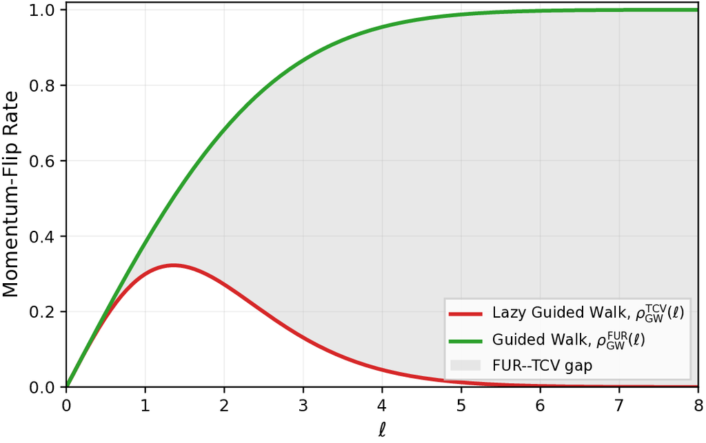

(a) Flip rate as a function of spacing.

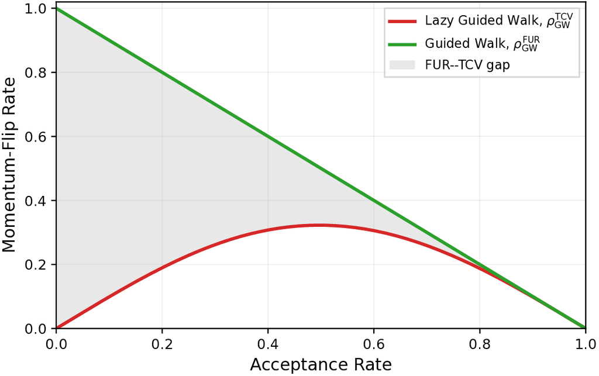

(b) Flip rate as a function of acceptance rate.

Figure 4: **TCV** flips are much **less frequent** as the spacing $\ell$ increases.

## LGW dominates Reversibility

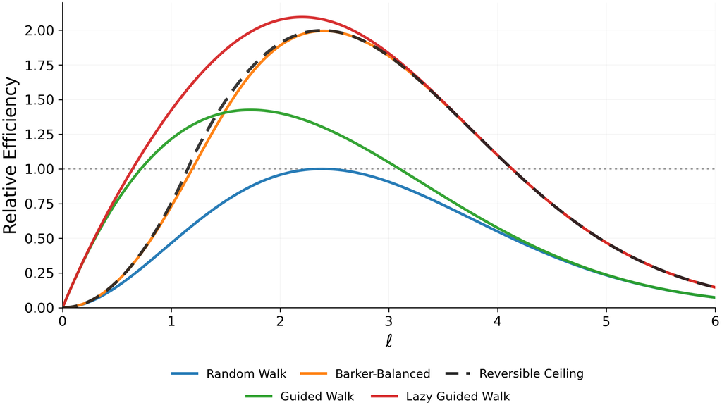

Figure 5

**Theorem** [QRT26+]. **Lazy Guided Walk** dominates **reversibility** for **any** spacing $\ell$.

## Towards an optimal skew-reversible kernel

**Efficiency metric:**

$$\mathrm{eff}(\ell) \;=\; \ell^2\Bigl(\textcolor{#1565c0}{a_+(\ell) + a_-(\ell)} + \frac{\textcolor{#2e7d32}{(a_+(\ell) - a_-(\ell))^2}}{\textcolor{#ef6c00}{\rho(\ell)}}\Bigr)$$

[figure not shown]

## Yielding Guided Walk [QRT26+]

[figure not shown]

1 $A_+(k)=\min\bigl\{1,\pi_{k+1}/\pi_k\bigr\}$ with momentum, as in **Guided Walk**

2 $1-\max\{A_+(k),A_-(k)\}$ stay, as in **Lazy Guided Walk**

3 $Y(k)=\dfrac{1}{\pi_k}\Bigl[\min\{\pi_k,\pi_{k-1}\}-\max\{\pi_{k+1},\pi_{k-2}\}\Bigr]_+$ against momentum: a **yielding** probability

with $\pi_k := \pi_{\beta_k}(x)$.

## Yielding Guided Walk in Practice

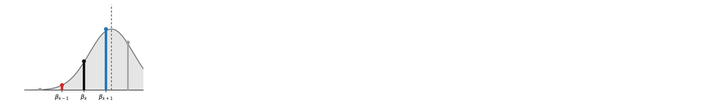

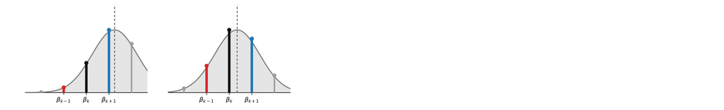

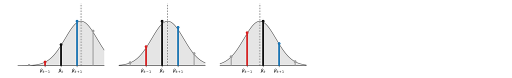

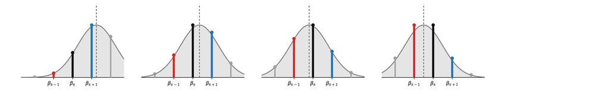

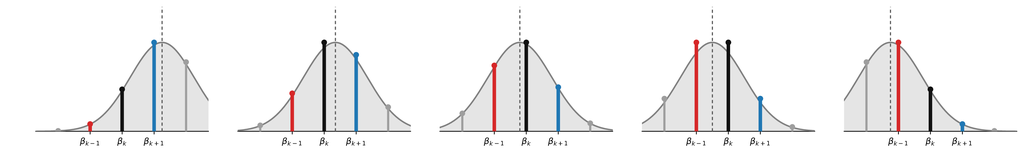

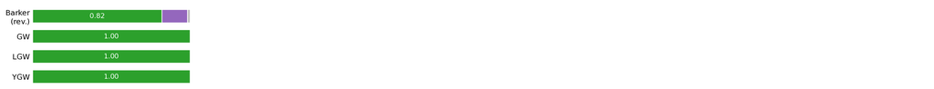

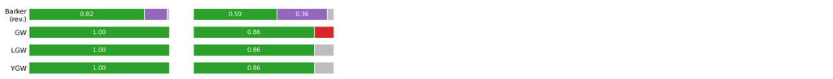

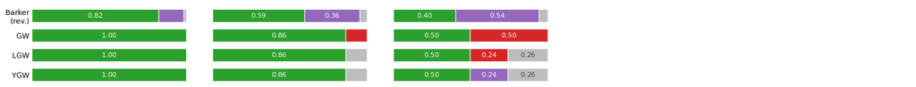

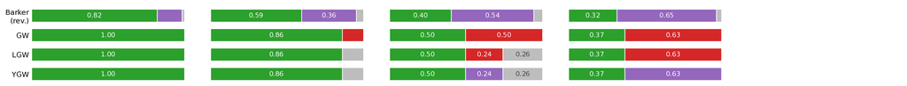

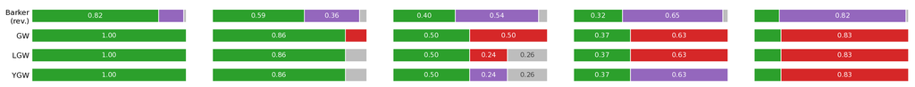

[figure not shown]

with $\pi_k := \pi_{\beta_k}(x)$.

## The Three Guided Walks [QRT26+]

|  | Guided Walk | Lazy Guided Walk | Yielding Guided Walk |
| --- | --- | --- | --- |
| Transition kernel from $(k,+)$ |  |  |  |
| Forward | $\boldsymbol{A_+}$ | $A_+$ | $A_+$ |
| Hold | $0$ | $\boldsymbol{1-\max\{A_+,A_-\}}$ | $1-\max\{A_+,A_-\}$ |
| Yield | $0$ | $0$ | $\boldsymbol{Y}$ |
| Flip | $1-A_+$ | $[A_--A_+]_+$ | $[A_--A_+]_+-Y$ |
| Criteria maximised |  |  |  |
| (i) With | ✔ | ✔ | ✔ |
| (ii) Lazy | ✘ | ✔ | ✔ |
| (iii) Against | ✘ | ✘ | ✔ |
| ST performance |  |  |  |
| Spacing $\ell^\star$ | $1.729$ | $2.202$ | $2.044$ |
| Efficiency (× RW) | $1.425$ | $2.094$ | $\mathbf{2.199}$ |

with $A_\pm=\min\{1,\pi_{k\pm1}/\pi_k\}$ and $Y=\bigl[\min\{\pi_k,\pi_{k-1}\}-\max\{\pi_{k+1},\pi_{k-2}\}\bigr]_+/\pi_k$. Efficiencies are at each walk’s own optimal spacing.

## Yielding and the Efficiency Ceiling [QRT26+]

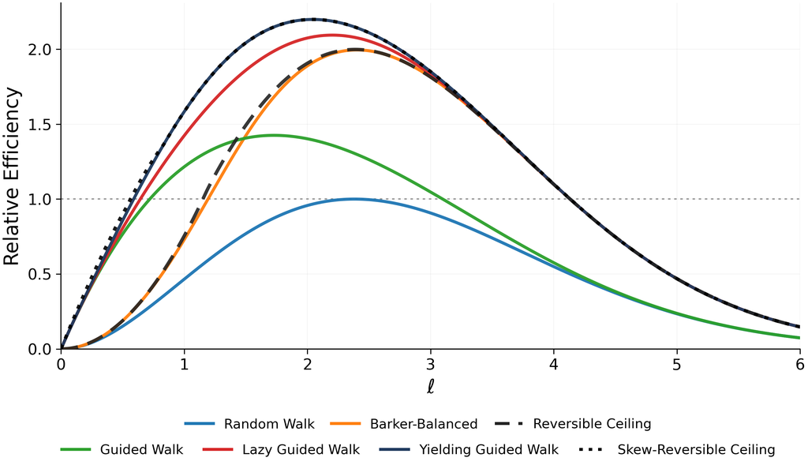

Figure 6

**Theorem** [QRT26+]. Skew-reversible kernels share a universal **efficiency ceiling**.

For $\textcolor{#ef6c00}{\ell \gtrsim 0.83}$, **Yielding Guided Walk** **attains it**.

## Asymptotic Transition Kernels

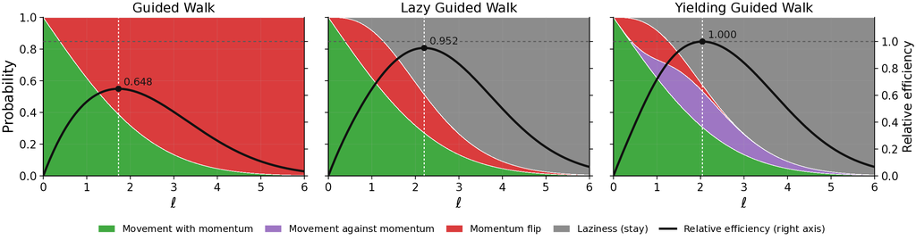

Figure 7: Transition kernels for Guided Walk, Lazy Guided Walk and Yielding Guided Walk.

## Summary Table of Efficiencies

|  | Optimal regime $\boldsymbol{\ell^\star}$ | Optimal regime $\boldsymbol{\mathrm{Acc}(\ell^\star)}$ | Optimal regime Relative efficiency | Transition probabilities $\boldsymbol{p_{\mathrm{with}}}$ | Transition probabilities $\boldsymbol{p_{\mathrm{against}}}$ | Transition probabilities $\boldsymbol{p_{\mathrm{flip}}}$ | Transition probabilities $\boldsymbol{p_{\mathrm{lazy}}}$ |
| --- | --- | --- | --- | --- | --- | --- | --- |
| Reversible methods |  |  |  |  |  |  |  |
| Random Walk | $2.38$ | $0.234$ | $0.455$ | — | — | — | $0.766$ |
| Barker-Balanced | $2.40$ | $0.459$ | $0.907$ | — | — | — | $0.541$ |
| *Reversible ceiling*† | $2.39$ | $0.465$ | $\mathbf{0.909}$ | — | — | — | $0.535$ |
| Non-reversible methods |  |  |  |  |  |  |  |
| Guided Walk | $1.73$ | $0.387$ | $0.648$ | $0.387$ | $0.000$ | $0.613$ | $0.000$ |
| Lazy Guided Walk | $2.20$ | $0.271$ | $0.952$ | $0.271$ | $0.000$ | $0.243$ | $0.486$ |
| **Yielding Guided Walk** | $2.04$ | $0.534$ | $\mathbf{1.000}$ | $0.307$ | $0.227$ | $0.039$ | $0.427$ |

† Theoretical upper bound attained by an oracle proposal, not by a practical kernel. Efficiencies are normalised by the optimal efficiency of Yielding Guided Walk.

# Empirical Results

## Toy Multivariate Gaussian [BCB25]

Gaussian prior & likelihood => **Gaussian at every $\textcolor{#1565c0}{\boldsymbol{\beta}}$**:

$$\pi_{\textcolor{#1565c0}{\beta}}=\mathrm N\!\big(\textcolor{#ef6c00}{\mu_\beta}\,\mathbf 1_d,\; \textcolor{#6a1b9a}{\sigma_\beta^2} I_d\big), \qquad
\textcolor{#6a1b9a}{\sigma_\beta^2}=\big(\textcolor{#1565c0}{\beta}+\sigma_0^{-2}\big)^{-1},
\quad
\textcolor{#ef6c00}{\mu_\beta}=\textcolor{#1565c0}{\beta}\,m\,\textcolor{#6a1b9a}{\sigma_\beta^2} .$$

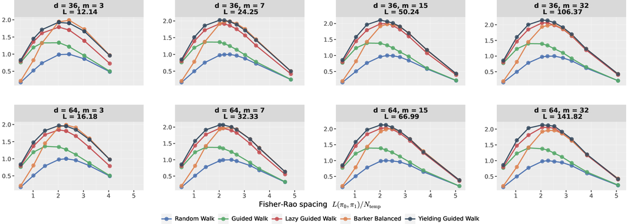

Figure 8: Scaled **round-trips** for **Random Walk**, **Guided Walk**, **Barker Balanced**, **Lazy Guided Walk** and **Yielding Guided Walk**.

## Running Example : Bimodal Gaussian

$d$-dimensional bimodal Gaussian mixture separated by $\textcolor{#ef6c00}{2\mu\sqrt{d}}$:

$$\pi(x)=\tfrac12\, \mathrm N\bigl(x;\,\textcolor{#1565c0}{\boldsymbol{+\mu\mathbf 1_d}},\, I_d\bigr)+\tfrac12\, \mathrm N\bigl(x;\,\textcolor{#c62828}{\boldsymbol{-\mu\mathbf 1_d}},\, I_d\bigr), \qquad \textcolor{#ef6c00}{\mu=d=16} .$$

[figure not shown]

**(a) Round trips** per million ST steps, against the acceptance rate α<sub>PT</sub> (left) and the spacing ℓ (right).

**(b) Mode switches** per million ST steps, against the acceptance rate α<sub>PT</sub> (left) and the spacing ℓ (right).

## Running Example : Bimodal Gaussian

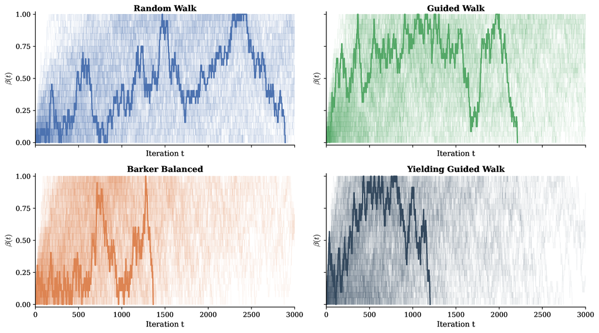

Figure 9: Round Trips for 101 ST chains.

## Toy multivariate Gaussian with AR(1)

**Non-immediate spatial mixing**: use an **AR(1)** step with correlation $\textcolor{#c62828}{\rho}$:

$$X^{(t+1)} = \textcolor{#ef6c00}{\mu(\beta^{(t)})} + \textcolor{#c62828}{\rho}\big( X^{(t)} - \textcolor{#ef6c00}{\mu(\beta^{(t)})} \big)
+ \textcolor{#6a1b9a}{\sigma(\beta^{(t)})}\textcolor{#c62828}{\sqrt{1-\rho^2}}\,\textcolor{#2e7d32}{\mathbf{Z}^{(t+1)}},
\qquad \textcolor{#2e7d32}{\mathbf{Z}^{(t+1)}} \sim \mathrm N(0,I).$$

[figure not shown]

# Takeaways & Further Work

## Takeaways

- **Locally-balanced proposals** (Barker) approach the optimal **reversible** efficiency.
- **Naive non-reversibility** (plain Guided Walk) is **dominated** by the best reversible kernels.
- Cutting the **flip rate** — **Lazy Guided Walk** — **beats every reversible method**.
- Allowing occasional **opposite-momentum** moves — **Yielding Guided Walk** — is **optimal** among nearest-neighbour skew-reversible kernels.

**Simulated Tempering temperature mixing stays bounded**.

## Future Work — Diagonal Moves

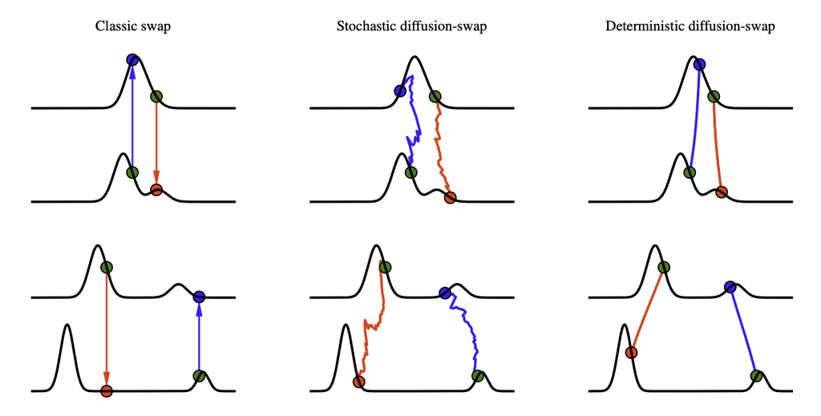

Illustration motivating diagonal temperature-state moves, Grenioux & Noble, 2026.

- **Diagonal moves**: Update **temperature and state jointly** [TR19; GN26] could **break the efficiency ceiling**. Potential ideas span **Reversible-Jump MCMC**, **normalizing flows** …

## Future Work — Reference Distributions and Paths

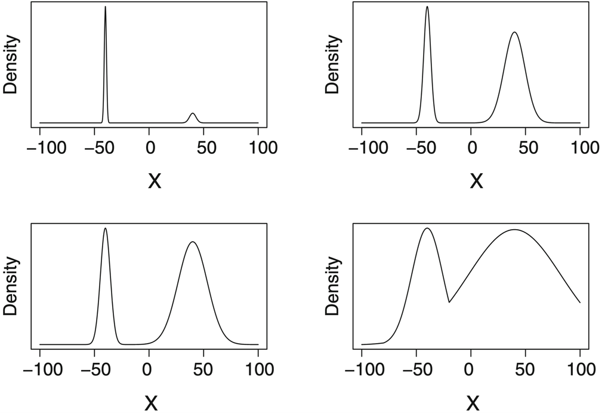

Weight degeneracy in Tempering, Tawn et. al, 2019.

- Global tempering degrades to **mode collapse** [WSH09]. Seek a **weight-preserving** scheme [TRR19], a **tractable** approximation to the target [SL26; TMQR26], a **variational reference** [SSBC22]?

## Thank you!

[figure not shown]

Slides

## References

[ARR11]

Atchadé, Roberts, & Rosenthal (2011). [Towards Optimal Scaling of Metropolis-Coupled Markov Chain Monte Carlo](https://doi.org/10.1007/s11222-010-9192-1). *Statistics and Computing* **21**.

[BCB25]

Biron-Lattes, Campbell, & Bouchard-Cote (2025). [Automatic Regenerative Simulation via Non-Reversible Simulated Tempering](https://doi.org/10.1080/01621459.2024.2335587). *Journal of the American Statistical Association* **120**.

[CLP99]

Chen, Lovasz, & Pak (1999). [Lifting Markov Chains to Speed up Mixing](https://doi.org/10.1145/301250.301315). In *Proceedings of the Thirty-First Annual ACM Symposium on Theory of Computing*.

[DHN00]

Diaconis, Holmes, & Neal (2000). [Analysis of a Nonreversible Markov Chain Sampler](https://doi.org/10.1214/aoap/1019487508). *The Annals of Applied Probability* **10**.

[FBDR20]

Faizi, Buigues, Deligiannidis, & Rosta (2020). [Simulated Tempering with Irreversible Gibbs Sampling Techniques](https://doi.org/10.1063/5.0025775). *The Journal of Chemical Physics* **153**.

[GN26]

Grenioux & Noble (2026). [Diffusion-Based Annealed Boltzmann Generators: Benefits, Pitfalls and Hopes](https://doi.org/10.48550/arXiv.2601.21026).

[GT95]

Geyer & Thompson (1995). [Annealing Markov Chain Monte Carlo with Applications to Ancestral Inference](https://doi.org/10.1080/01621459.1995.10476590). *Journal of the American Statistical Association* **90**.

[Gus98]

Gustafson (1998). [A Guided Walk Metropolis Algorithm](https://doi.org/10.1023/A:1008880707168). *Statistics and Computing* **8**.

[KT90]

Kimura & Taki (1990). *On a Time-Homogeneous Parallel Annealing Algorithm*.

[LDMT09b]

Lingenheil, Denschlag, Mathias, & Tavan (2009). [Efficiency of Exchange Schemes in Replica Exchange](https://doi.org/10.1016/j.cplett.2009.07.039). *Chemical Physics Letters* **478**.

[MP92]

Marinari & Parisi (1992). [Simulated Tempering: A New Monte Carlo Scheme](https://doi.org/10.1209/0295-5075/19/6/002). *Europhysics Letters* **19**.

[MRR+53]

Metropolis, Rosenbluth, Rosenbluth, Teller, & Teller (1953). [Equation of State Calculations by Fast Computing Machines](https://doi.org/10.1063/1.1699114). *The Journal of Chemical Physics* **21**.

[QRT26+]

[RR01]

Roberts & Rosenthal (2001). [Optimal Scaling for Various Metropolis-Hastings Algorithms](https://doi.org/10.1214/ss/1015346320). *Statistical Science* **16**.

[RR14]

Roberts & Rosenthal (2014). [Minimising MCMC Variance via Diffusion Limits, with an Application to Simulated Tempering](https://doi.org/10.1214/13-AAP918). *The Annals of Applied Probability* **24**.

[RR25]

Roberts & Rosenthal (2025). [Quantifying the Speed-Up from Non-Reversibility in MCMC Tempering Algorithms](https://doi.org/10.48550/arXiv.2501.16506).

[RRT22]

Roberts, Rosenthal, & Tawn (2022). [Skew Brownian Motion and Complexity of the Alps Algorithm](https://doi.org/10.1017/jpr.2021.78). *Journal of Applied Probability* **59**.

[SBDD22]

Syed, Bouchard-Côté, Deligiannidis, & Doucet (2022). [Non-Reversible Parallel Tempering: A Scalable Highly Parallel MCMC Scheme](https://doi.org/10.1111/rssb.12464). *Journal of the Royal Statistical Society Series B: Statistical Methodology* **84**.

[SH16]

Sakai & Hukushima (2016). [Irreversible Simulated Tempering](https://doi.org/10.7566/JPSJ.85.104002). *Journal of the Physical Society of Japan* **85**.

[SL26]

[SSBC22]

Surjanovic, Syed, Bouchard-Côté, & Campbell (2022). Parallel Tempering with a Variational Reference. In *Proceedings of the 36th International Conference on Neural Information Processing Systems*.

[TCV11]

Turitsyn, Chertkov, & Vucelja (2011). [Irreversible Monte Carlo Algorithms for Efficient Sampling](https://doi.org/10.1016/j.physd.2010.10.003). *Physica D: Nonlinear Phenomena* **240**.

[TMQR26]

Tawn, Moores, Queniat, & Roberts (2026). [Annealed Leap-Point Sampler for Multimodal Target Distributions](https://doi.org/10.1007/s11222-026-10988-5). *Statistics and Computing* **36**.

[TR19]

Tawn & Roberts (2019). [Accelerating Parallel Tempering: Quantile Tempering Algorithm](https://doi.org/10.1017/apr.2019.35). *Advances in Applied Probability* **51**.

[TRR19]

Tawn, Roberts, & Rosenthal (2019). [Weight-Preserving Simulated Tempering](https://doi.org/10.1007/s11222-019-09863-3). *Statistics and Computing* **30**.

[WSH09]

Woodard, Schmidler, & Huber (2009). [Sufficient Conditions for Torpid Mixing of Parallel and Simulated Tempering](https://doi.org/10.1214/EJP.v14-638). *Electronic Journal of Probability* **14**.

[Zan20]

Zanella (2020). [Informed Proposals for Local MCMC in Discrete Spaces](https://doi.org/10.1080/01621459.2019.1585255). *Journal of the American Statistical Association* **115**.